# Homework 1 - IE 360

Emre Karadas

2022-04-13

## 1. Introduction

First of all, I would like to tell you why I chose these data. The day I listened to the explanation of the assignment in class, an article about the unemployment rate in Turkey caught my attention. When I thought about this topic afterwards, I thought that for the unemployment rate to increase, there should be more liquidated companies than newly established companies. So, I decided to examine the relationship between these data.

When the unemployment rate increases, should the number of newly opened companies be less than the number of liquidated companies? In this case, how much did people search for the term “unemployment rate” on google? In order to find an answer to the question in my mind, I analyzed the relationship between data. While doing these analyzes, I examined 4 different data on https://evds2.tcmb.gov.tr/ and https://trends.google.com/trends/.

The names of these data are: Search Number of “Unemployment Rate” on Google, Unemployment Rate, Total Number of Newly Established Firms, Total Number of Liquidated Firms.

## Used Packages

```r
library(zoo,warn.conflicts = FALSE)
library(readxl)
library(ggplot2)
library(lubridate)
library(corrplot)
```

I assigned the data to the specific variables to understand easily.

## Related Data

```r
UnemploymentRateSearch <- read.csv("UnemploymentRateSearch.csv")
UnemploymentRateSearch$Date <- as.yearmon(UnemploymentRateSearch$Date)

EstablishedFirms <- read_excel("EstablishedFirms.xlsx")
EstablishedFirms$Date <- as.yearmon(EstablishedFirms$Date)

LiquidatedFirms <- read_excel("LiquidatedFirms.xlsx")
LiquidatedFirms$Date <- as.yearmon(LiquidatedFirms$Date)

UnemploymentRate <- read_excel("UnemploymentRate.xlsx")
UnemploymentRate$Date <- as.yearmon(UnemploymentRate$Date)
```

## 2. Google Trends Result for İssizlik Orani / 2017-2022 / Monthly

## 2.1 Summary

```r
head(UnemploymentRateSearch, 6)
```

```
##       Date Index
## 1 Oca 2017    33
## 2 Şub 2017    38
## 3 Mar 2017    69
## 4 Nis 2017    53
## 5 May 2017    44
## 6 Haz 2017    25
```

```r
## First Six Months Data
```

```r
tail(UnemploymentRateSearch, 6)
```

```
##        Date Index
## 56 Ağu 2021    43
## 57 Eyl 2021    30
## 58 Eki 2021    33
## 59 Kas 2021    33
## 60 Ara 2021    26
## 61 Oca 2022    28
```

```r
## Last Six Months Data
```

```r
summary(UnemploymentRateSearch$Index)
```

```
##    Min. 1st Qu.  Median    Mean 3rd Qu.    Max.
##   24.00   33.00   41.00   42.11   50.00   78.00
```

```r
## Summary of Google Trends Result for İssizlik Orani
```

## 2.2 Box-Plotted Data

[figure not shown]

```r
ggplot(UnemploymentRateSearch, aes(x=factor(year(Date)),y=Index)) +
geom_boxplot(aes(fill=factor(year(Date)))) +
xlab("Years") + ylab("Index") +
ggtitle("Google Trends Result for Issizlik Orani") +
theme_linedraw() + theme(legend.position = "none")
```

## 2.3 Plotted Data

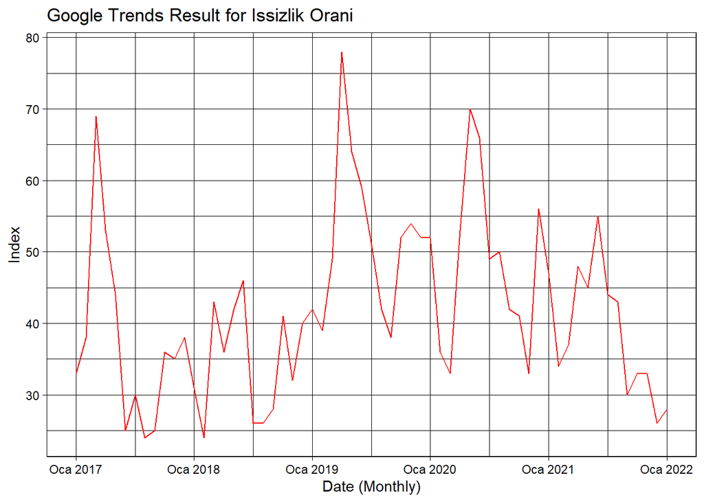

```r
ggplot(UnemploymentRateSearch, aes(Date, Index)) +
geom_line(data = UnemploymentRateSearch, color="red", linetype = "solid") +
ggtitle("Google Trends Result for Issizlik Orani") +
xlab("Date (Monthly)") +
ylab("Index") +
theme_linedraw()
```

## 3. Total Number of New Established Firms / 2017-2022 / Monthly

## 3.1 Summary

```r
head(EstablishedFirms, 6)
```

```
## # A tibble: 6 x 2
##   Date          Total_Established_Firms
##   <S3: yearmon>                   <dbl>
## 1 Oca 2017                         6275
## 2 Şub 2017                         5617
## 3 Mar 2017                         6146
## 4 Nis 2017                         6446
## 5 May 2017                         6250
## 6 Haz 2017                         6039
```

```r
## First Six Months Data
```

```r
tail(EstablishedFirms, 6)
```

```
## # A tibble: 6 x 2
##   Date          Total_Established_Firms
##   <S3: yearmon>                   <dbl>
## 1 Ağu 2021                         8900
## 2 Eyl 2021                        10316
## 3 Eki 2021                         9463
## 4 Kas 2021                        10302
## 5 Ara 2021                         9905
## 6 Oca 2022                        11526
```

```r
## Last Six Months Data
```

```r
summary(EstablishedFirms$Total_Established_Firms)
```

```
##    Min. 1st Qu.  Median    Mean 3rd Qu.    Max.
##    2878    6394    7301    7719    9463   11526
```

```r
## Summary of New Established Firms
```

## 3.2 Box-Plotted Data

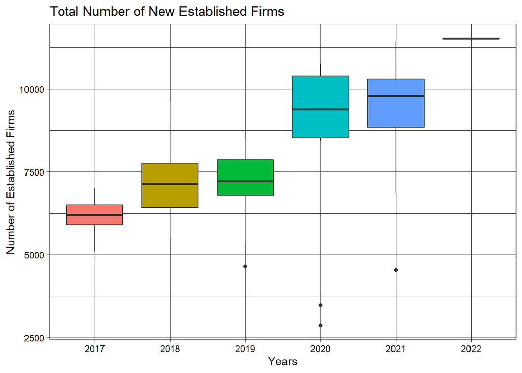

```r
ggplot(EstablishedFirms, aes(x=factor(year(Date)),y=Total_Established_Firms)) +
geom_boxplot(aes(fill=factor(year(Date)))) +
xlab("Years") + ylab("Number of Established Firms") +
ggtitle("Total Number of New Established Firms") +
theme_linedraw() + theme(legend.position = "none")
```

## 3.3 Plotted Data

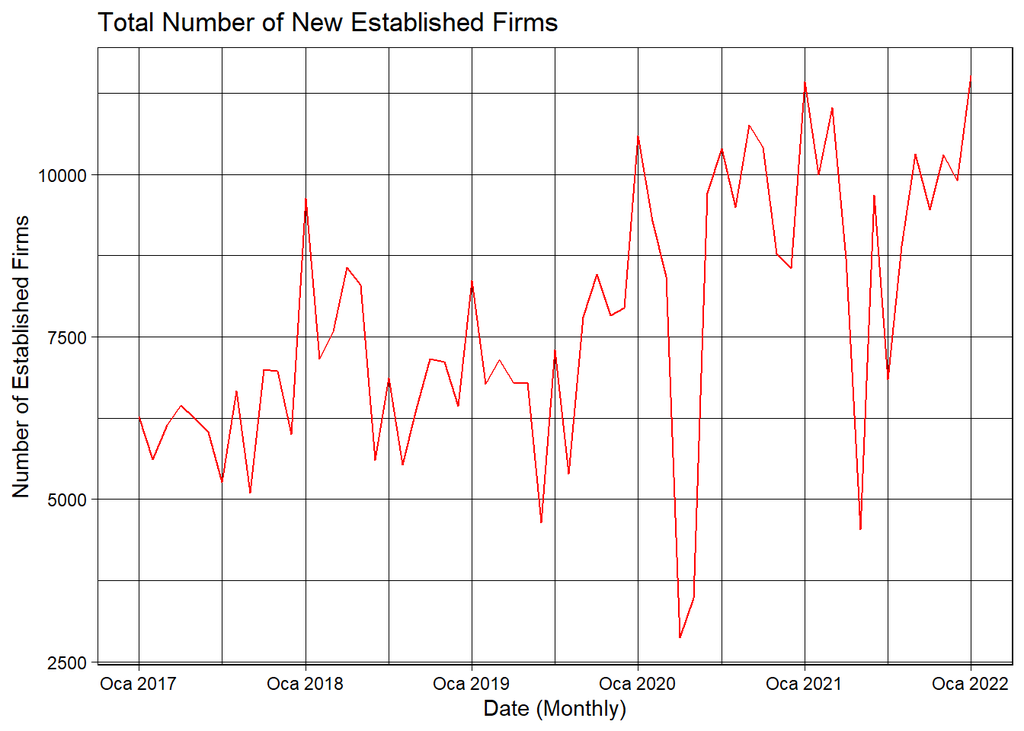

```r
ggplot(EstablishedFirms, aes(Date, Total_Established_Firms)) +
geom_line(data = EstablishedFirms, color="red", linetype = "solid") +
ggtitle("Total Number of New Established Firms") +
xlab("Date (Monthly)") +
ylab("Number of Established Firms") +
theme_linedraw()
```

## 4. Total Number of Liquidated Firms / 2017-2022 / Monthly

## 4.1 Summary

```r
head(LiquidatedFirms, 6)
```

```
## # A tibble: 6 x 2
##   Date          Total_Liquidated_Firms
##   <S3: yearmon>                  <dbl>
## 1 Oca 2017                        2142
## 2 Şub 2017                         815
## 3 Mar 2017                         720
## 4 Nis 2017                         810
## 5 May 2017                         861
## 6 Haz 2017                        1112
```

```r
## First Six Months Data
```

```r
tail(LiquidatedFirms, 6)
```

```
## # A tibble: 6 x 2
##   Date          Total_Liquidated_Firms
##   <S3: yearmon>                  <dbl>
## 1 Ağu 2021                        1442
## 2 Eyl 2021                        1687
## 3 Eki 2021                        1599
## 4 Kas 2021                        1661
## 5 Ara 2021                        4057
## 6 Oca 2022                        1088
```

```r
## Last Six Months Data
```

```r
summary(LiquidatedFirms$Total_Liquidated_Firms)
```

```
##    Min. 1st Qu.  Median    Mean 3rd Qu.    Max.
##     427     815    1112    1255    1375    4057
```

```r
## Summary of Liquidated Firms
```

## 4.2 Box-Plotted Data

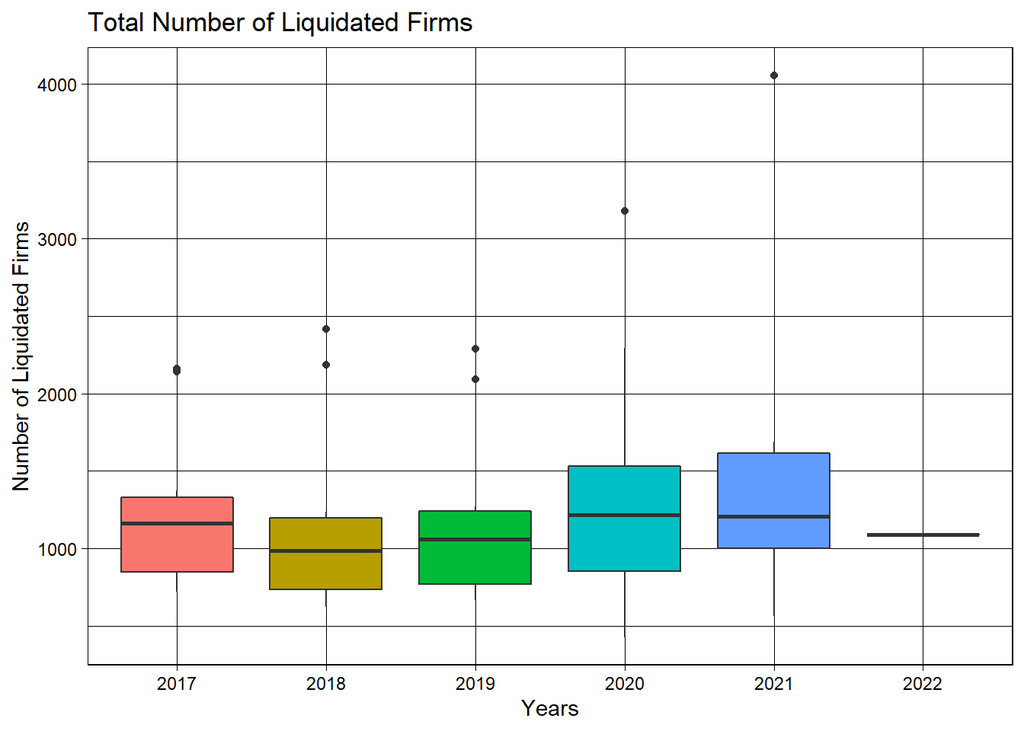

```r
ggplot(LiquidatedFirms, aes(x=factor(year(Date)),y=Total_Liquidated_Firms)) +
geom_boxplot(aes(fill=factor(year(Date)))) +
xlab("Years") + ylab("Number of Liquidated Firms") +
ggtitle("Total Number of Liquidated Firms") +
theme_linedraw() + theme(legend.position = "none")
```

## 4.3 Plotted Data

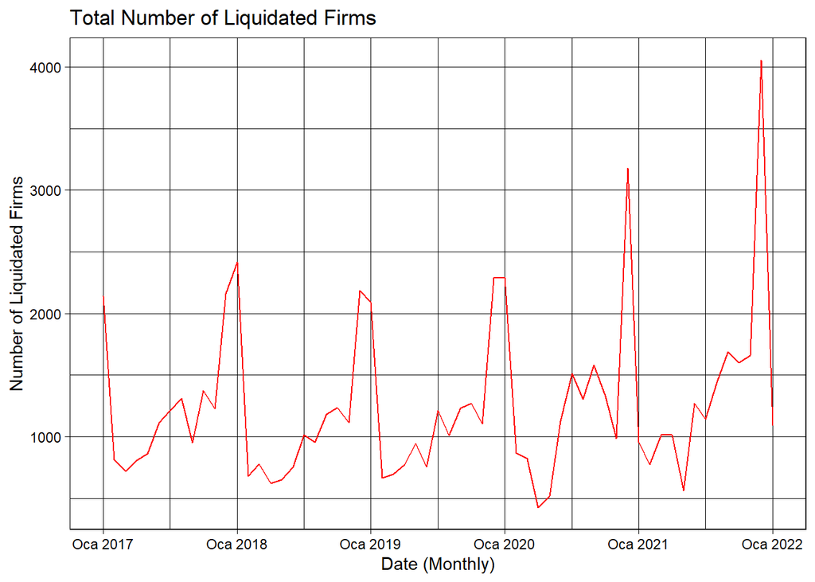

```r
ggplot(LiquidatedFirms, aes(Date, Total_Liquidated_Firms)) +
geom_line(data = LiquidatedFirms, color="red", linetype = "solid") +
ggtitle("Total Number of Liquidated Firms") +
xlab("Date (Monthly)") +
ylab("Number of Liquidated Firms") +
theme_linedraw()
```

## 5. Unemployment Rate / 2017-2022 / Monthly

## 5.1 Summary

```r
head(UnemploymentRate, 6)
```

```
## # A tibble: 6 x 2
##   Date          Unemployment_Rate
##   <S3: yearmon>             <dbl>
## 1 Oca 2017                   13.5
## 2 Şub 2017                   12.9
## 3 Mar 2017                   11.7
## 4 Nis 2017                   10.5
## 5 May 2017                    9.7
## 6 Haz 2017                   10.4
```

```r
## First Six Months Data
```

```r
tail(UnemploymentRate, 6)
```

```
## # A tibble: 6 x 2
##   Date          Unemployment_Rate
##   <S3: yearmon>             <dbl>
## 1 Ağu 2021                   12
## 2 Eyl 2021                   11.1
## 3 Eki 2021                   10.7
## 4 Kas 2021                   10.9
## 5 Ara 2021                   11.3
## 6 Oca 2022                   12.1
```

```r
## Last Six Months Data
```

```r
summary(UnemploymentRate$Unemployment_Rate)
```

```
##    Min. 1st Qu.  Median    Mean 3rd Qu.    Max.
##    9.30   10.70   12.40   12.15   13.30   15.10
```

```r
## Summary of Unemployment Rate
```

## 5.2 Box-Plotted Data

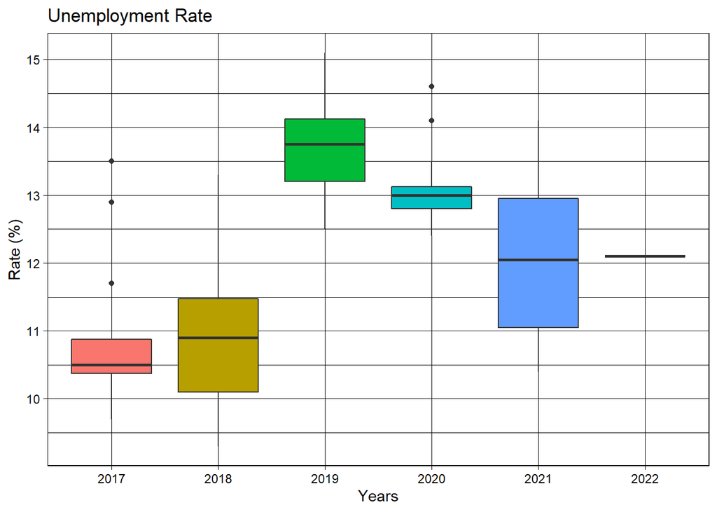

```r
ggplot(UnemploymentRate, aes(x=factor(year(Date)),y=Unemployment_Rate)) +
geom_boxplot(aes(fill=factor(year(Date)))) +
xlab("Years") + ylab("Rate (%)") +
ggtitle("Unemployment Rate") +
theme_linedraw() + theme(legend.position = "none")
```

## 5.3 Plotted Data

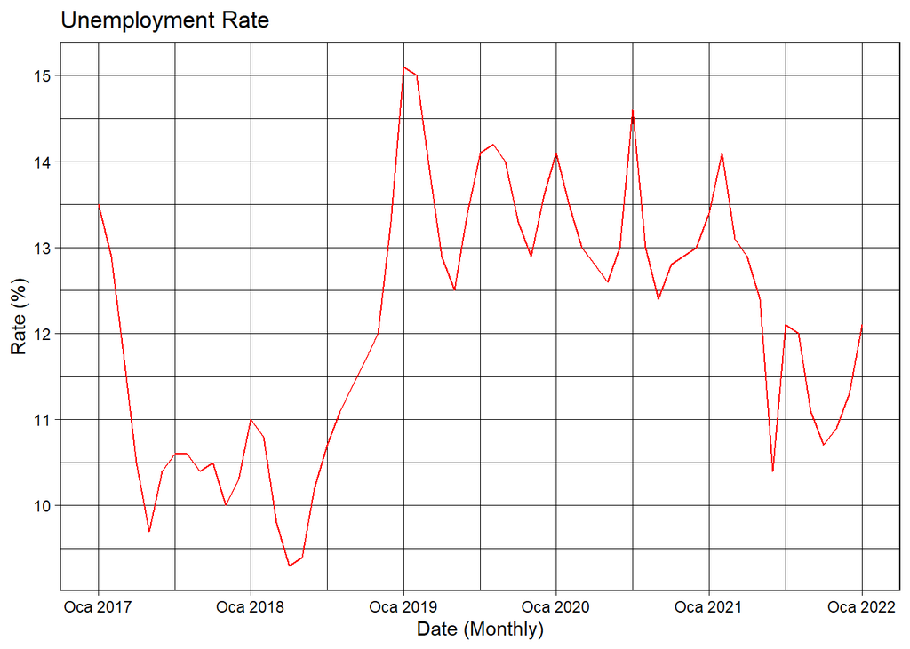

```r
ggplot(UnemploymentRate, aes(Date, Unemployment_Rate)) +
geom_line(data = UnemploymentRate, color="red", linetype = "solid") +
ggtitle("Unemployment Rate") +
xlab("Date (Monthly)") +
ylab("Rate (%)") +
theme_linedraw()
```

## 6. Correlation Matrix

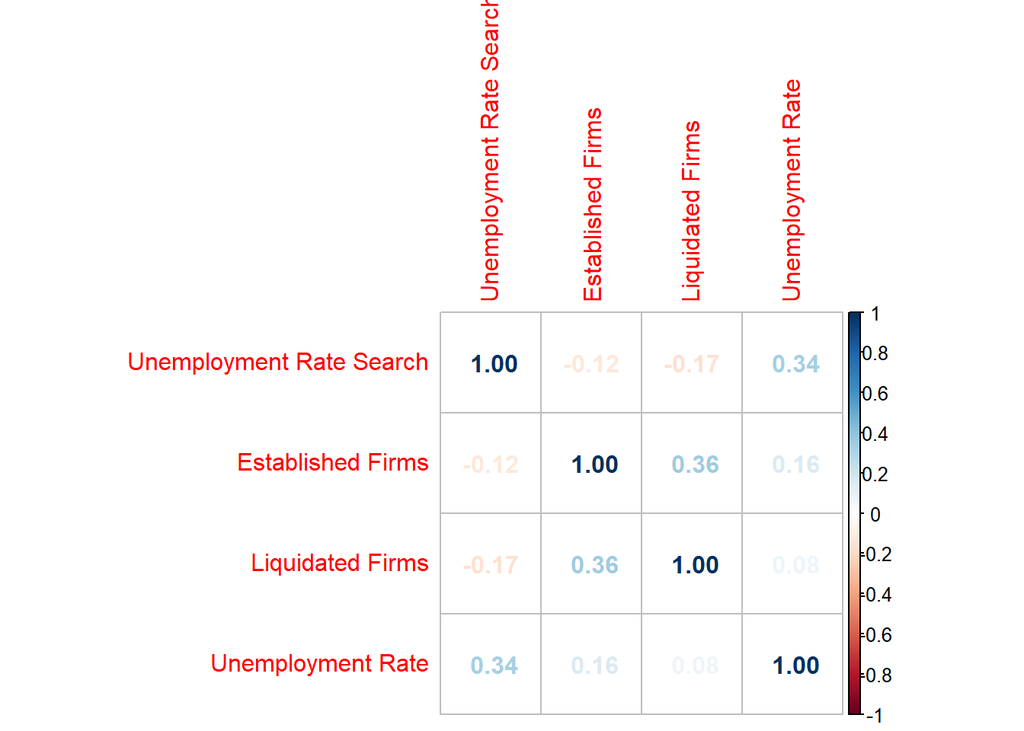

```r
data <- data.frame( UnemploymentRateSearch$Index,  EstablishedFirms$Total_Established_Firms, LiquidatedFirms$Total_Liquidated_Firms, UnemploymentRate$Unemployment_Rate)
names(data) <- c("Unemployment Rate Search", "Established Firms", "Liquidated Firms" , "Unemployment Rate")
corrplot(cor(data), method="number")
```

## 7. Conclusion

First of all, I showed first and last 6 months data for each data set . Then I listed min, max, median and mean values for each data set which I get from https://evds2.tcmb.gov.tr/ and https://trends.google.com/trends/ to analyze in my report.

Secondly, I plotted data in two different way which are box plot and line plot with the help of RStudio. With the help of plotting data, I could see the data visually. Therefore, data plotting helped me to understand what data say.

Finally, I created correlation matrix to see relationship between these 4 data. However, when I look at the correlation matrix results, I saw that I reached a different result from the idea that I thought when choosing these data. By looking at correlation matrix, it can be seen that maximum correlation is 0.36. So, contrary to my thought, I saw that the data do not have strong connections with each other.